# 3-neopir-dolan.Rmd

Johannes Titz

12/13/2021

This is analysis 3 of the paper. If you have not yet installed the `star` package, do it now:

```r
if (require("star") == F) {
  install.packages("star_0.1.0.tar.gz", repos = NULL, type = "source")
}
```

The original data set is available in the `qgraph` R package. I restructured the data slightly and repackaged it into `star` under the same name as in `qgraph` (big5):

```r
library(star)
data(big5, package = "star")
```

Load some packages and use a short name for the data set. I will use librarian for installing/loading packages. First line checks if librarian is installed, if not, it is installed.

```r
if (!require('librarian')) install.packages('librarian')
librarian::shelf(tidyr, dplyr, ggplot2, cowplot, simpleCache)
data("neo_pi_r_eugene")
neo <- big5
```

The data set does not contain many missing values.

```r
missing <- rowSums(is.na(neo))
stem(missing)
```

```
##
##   The decimal point is at the |
##
##   0 | 00000000000000000000000000000000000000000000000000000000000000000000+320
##   0 |
##   1 | 00000000000000000000000000000000000000000000000000000000000000000000
##   1 |
##   2 | 0000000000
##   2 |
##   3 | 0000
##   3 |
##   4 | 000000000000
##   4 |
##   5 | 0000
##   5 |
##   6 | 0
```

Set cache dir for simpleCache:

```r
setCacheDir("cache_dolan")
```

Set simulation parameters. I am on GNU/Linux, please check that the detection of cores works for you. If it does not work, just set it to a fixed value. `star` uses the `parallel` for parallel computation. Sorry, Windows users, parallelization only works under GNU/Linux. You should still be able to run the code, but you cannot take advantage of multiple cores. I tried to implement parallelization via futures (`furrr`), but this turned out to be slower than using a single core.

```r
mc_cores <- round(parallel::detectCores() - 1)
alpha <- 0.05 / 240
param <- sim_parameters(n_bootstrap_samples = 1e4, mc_cores = mc_cores)
set.seed(5989)
```

## Test 1: A144 against trust

```r
simpleCache("a144", {
  test_specific_items(neo, rep("A144", 8), paste("A", seq(4, 214, 30), sep = ""),
                      param)
  })
knitr::kable(a144, digits = 4)
```

| i | j | .id | p | deviance_data | n | partial_deviances.1 | partial_deviances.2 | partial_deviances.3 | partial_deviances.4 | partial_deviances.5 | n_min_violated | var0 | p_aggregated | aggregated_deviance |
| --- | --- | --- | --- | --- | --- | --- | --- | --- | --- | --- | --- | --- | --- | --- |
| A144 | A4 | A144 | 0.0033 | 17.5167 | 838 | 0.0000 | 1.1191 | 0.1248 | 0.0421 | 16.2307 | 0 | 0 | 0 | 92.0511 |
| A144 | A34 | A144 | 0.0007 | 15.9506 | 840 | 0.0000 | 2.6711 | 0.0023 | 0.7693 | 12.5079 | 0 | 0 | 0 | 92.0511 |
| A144 | A64 | A144 | 0.0049 | 13.2826 | 837 | 0.2026 | 2.2930 | 0.2205 | 2.9514 | 7.6151 | 0 | 0 | 0 | 92.0511 |
| A144 | A94 | A144 | 0.0060 | 8.3225 | 843 | 0.2223 | 2.2563 | 0.1606 | 0.9301 | 4.7532 | 0 | 0 | 0 | 92.0511 |
| A144 | A124 | A144 | 0.0090 | 9.2753 | 840 | 2.4526 | 1.6622 | 0.2590 | 1.3964 | 3.5050 | 0 | 0 | 0 | 92.0511 |
| A144 | A154 | A144 | 0.0359 | 7.9689 | 840 | 0.0000 | 1.3456 | 0.0002 | 0.3197 | 6.3034 | 0 | 0 | 0 | 92.0511 |
| A144 | A184 | A144 | 0.0604 | 5.5651 | 836 | 1.4465 | 0.9160 | 0.0534 | 1.0692 | 2.0800 | 0 | 0 | 0 | 92.0511 |
| A144 | A214 | A144 | 0.0032 | 14.1694 | 838 | 1.3703 | 3.0421 | 0.0202 | 3.0291 | 6.7077 | 0 | 0 | 0 | 92.0511 |

The significance tests gives a residual of 92.0511188 and a $p$-value of 0.

## Test 2: values versus ideas

```r
o6 <- paste0("O", seq(28, 238, 30))
o5 <- paste0("O", seq(23, 233, 30))
comps <- expand.grid(o6, o5, stringsAsFactors = F)
simpleCache("valuesideas", {
  test_specific_items(neo, comps$Var1, comps$Var2,
                      param)
  })
```

The significance tests gives a residual of 75.1360198 and a $p$-value of 0.5345.

## Test items against dimensions with 10 bootstrap samples

Only 10 bootstrap samples are used to quickly filter out non-significant items:

```r
param$n_bootstrap_samples <- 10
simpleCache("neo_pi_r10",
            {test_items_against_dimension(names(neo), neo, param)})
left_items <- extract_sig_items(neo_pi_r10, 0.2)
```

Check how many items could not be tested properly:

```r
neo_pi_r10 %>%
  group_by(i) %>%
  summarize(warn = mean(var0 + n_min_violated > 0)) %>%
  filter(warn > 0)
```

```
## # A tibble: 51 × 2
##    i       warn
##    <chr>  <dbl>
##  1 A104  1
##  2 A109  1
##  3 A124  1
##  4 A129  0.0426
##  5 A164  1
##  6 A194  1
##  7 A204  1
##  8 A209  1
##  9 A224  1
## 10 A229  1
## # … with 41 more rows
```

## 100

```r
param$n_bootstrap_samples <- 1e2
simpleCache("neo_pi_r100",
            {test_items_against_dimension(left_items, neo, param)})
left_items <- extract_sig_items(neo_pi_r100, 0.05)
```

## 1k

```r
param$n_bootstrap_samples <- 1e3
simpleCache("neo_pi_r1k",
            {test_items_against_dimension(left_items, neo, param)})
left_items <- extract_sig_items(neo_pi_r1k, 0.005)
```

## 20k

```r
param$n_bootstrap_samples <- 2e4
simpleCache("neo_pi_r20k",
            {test_items_against_dimension(left_items, neo, param)})
neo_pi_r20k <- neo_pi_r20k %>% filter(p_aggregated <= alpha)
```

## Create results table

```r
neo_pi_r20k_agg <- neo_pi_r20k %>% group_by(i) %>%
  select(i, j, p, aggregated_deviance, p_aggregated, n_min_violated, var0, n) %>%
  slice(1) %>%
  ungroup() %>%
  transmute(Item = factor(i, levels = stringr::str_sort(i, numeric = TRUE)),
            p = format.pval(p_aggregated, digits = 4, eps = 5e-5, scientific = F),
            Deviance = aggregated_deviance, n_min_violated, var0, n) %>%
  arrange(Item)
neo_pi_r20k_agg
```

```
## # A tibble: 9 × 6
##   Item  p         Deviance n_min_violated  var0     n
##   <fct> <chr>        <dbl>          <int> <int> <int>
## 1 A99   < 0.00005     90.7              0     0   840
## 2 A129  < 0.00005    144.               0     0   840
## 3 A144  < 0.00005    133.               0     0   838
## 4 A164  0.00005       71.2              1     1   838
## 5 C35   < 0.00005    119.               0     0   842
## 6 E2    < 0.00005    150.               0     0   842
## 7 E17   < 0.00005    227.               0     0   845
## 8 N31   0.0001        98.0              0     0   841
## 9 N96   < 0.00005    179.               0     0   838
```

```r
neo_pi_r20k_agg <- neo_pi_r20k_agg %>% select(-n_min_violated, -var0, -n)
res <- xtable::xtable(
  neo_pi_r20k_agg,
  caption = "Items That Significantly Violate Monotonicity in the Revised Dutch NEO Personality Inventory Data Set at an $\\alpha$ of .000208",
  label = "tab:neo_pi_r_dolan2",
  digits = c(0, 0, 3, 3), align = "llrr"
)
print(res, include.rownames = F, booktabs = TRUE, file = "tables/dolan.tex",
      caption.placement = "top", label = "tab:neo_pi_r_dolan2")
```

## partial fits plot

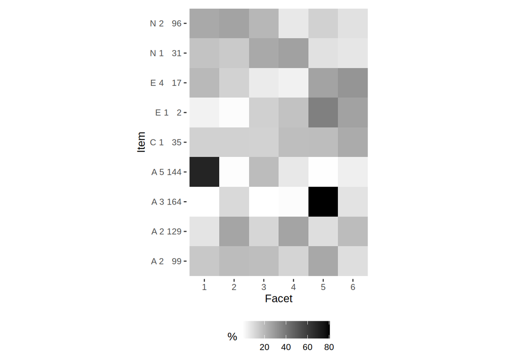

```r
# second plot
partial <- neo_pi_r20k %>% filter(deviance_data != 0)
small <- tidyr::pivot_longer(partial, cols = partial_deviances.1:partial_deviances.5)

items <- create_neo_pi_r_items()
small2 <- left_join(small, items, by = c("j" = "item_char")) %>%
  arrange(i, facet, facet_item) %>%
  mutate(label = as.factor(paste(facet, facet_item, item_number)))

small3 <- small2 %>% group_by(i, j) %>% mutate(value_percent = value / aggregated_deviance)

small4 <- small2 %>% group_by(i, facet) %>% summarize(value_percent = sum(value/aggregated_deviance, na.rm=T))
small5 <- left_join(small4, items, by = c("i" = "item_char"))

small5 <- mutate(small5,
                 label = ifelse(nchar(i) == 4,
                                paste(dimension, facet.y, item_number),
                                paste(dimension, " ", facet.y, "   ", item_number, sep = "")),
                 value_percent = value_percent * 100)

p2 <- ggplot(small5, aes(as.factor(facet.x), label, fill = value_percent)) +
  geom_raster() +
  coord_equal() +
  scale_fill_gradient(name = "%", low = "white", high = "black", na.value = "white") +
  scale_x_discrete(name = "Facet", labels = 1:6) +
  scale_y_discrete(name = "Item", position = "left") +
  theme(legend.position = "right")+
  theme(legend.position = "bottom",
        #axis.text.y=element_blank(),
        #axis.title.y=element_blank(),
        panel.background=element_blank(),
        panel.border=element_blank()
        #text = element_text(size = 20)
        )
p2
```

```r
pdf("plots/dolan_partial.pdf", width = 7*0.7, height = 9)
p2
dev.off()
```

## some examples

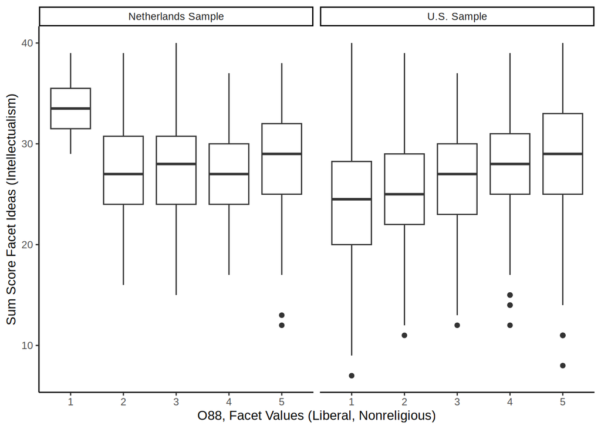

```r
data("neo_pi_r_eugene")
sum_score <- rowSums(big5[, paste("O", seq(23, 233, 30), sep="")], na.rm = T)

sum_score_eugene <- rowSums(neo_pi_r_eugene[, paste("O", seq(23, 233, 30), sep="")], na.rm = T)
d <- rbind(data.frame(facet5 = sum_score, questionnaire = "Netherlands Sample",
                      O88 = big5$O88, O18 = big5$O18),
           data.frame(facet5 = sum_score_eugene, questionnaire = "U.S. Sample",
                      O88 = neo_pi_r_eugene$O88, O18 = neo_pi_r_eugene$O18))
d <- na.omit(d)
p1 <- ggplot(d, aes(as.factor(O88), facet5)) + geom_boxplot() + facet_wrap(~questionnaire) +
  theme_classic() +
  scale_x_discrete("O88, Facet Values (Liberal, Nonreligious)") +
  scale_y_continuous("Sum Score Facet Ideas (Intellectualism)")

p2 <- ggplot(d, aes(as.factor(O18), facet5)) + geom_boxplot() + facet_wrap(~questionnaire) +
  theme_classic() +
  scale_x_discrete("O18, Facet Actions (Nonroutine)") +
  scale_y_continuous("Sum Score Facet Ideas (Intellectualism)")
p1
```

```r
table(d$O88, d$questionnaire)
```

```
##
##     Netherlands Sample U.S. Sample
##   1                  8          68
##   2                 38         151
##   3                126         164
##   4                119         253
##   5                206         210
```

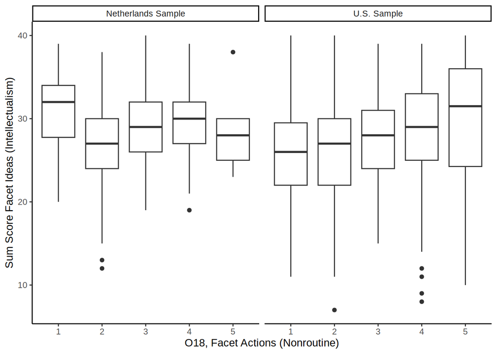

```r
p2
```

```r
table(d$O18, d$questionnaire)
```

```
##
##     Netherlands Sample U.S. Sample
##   1                 24          51
##   2                311         419
##   3                 98         166
##   4                 59         196
##   5                  5          14
```

```r
pdf("plots/dolan_boxplots.pdf", width = 7, height = 7)
gridExtra::grid.arrange(p1, p2)
dev.off()
```

## openness

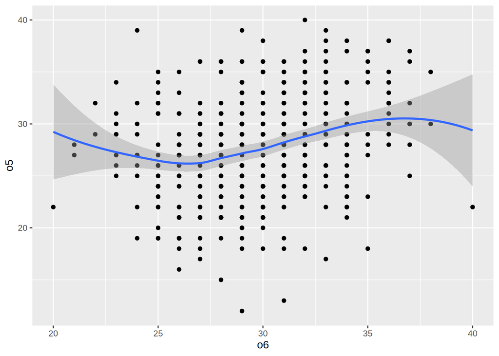

```r
o5 <- paste0("O", seq(23, by = 30, length.out = 8))
o6 <- paste0("O", seq(28, by = 30, length.out = 8))

sum_score <- neo %>% select(all_of(o5)) %>% rowSums(na.rm = TRUE)
sum_score_o6 <- neo %>% select(all_of(o6)) %>% rowSums(na.rm = TRUE)

df <- data.frame(o6 = sum_score_o6, o5 = sum_score)

ggplot(df, aes(o6, o5)) +
  geom_point() +
  geom_smooth()
```

```r
cor(df, use = "complete.obs")
```

```
##          o6       o5
## o6 1.000000 0.253527
## o5 0.253527 1.000000
```